# Regression with Bayesian Approach

Vedant Kansara

2022-12-13

## Load Packages

```r
library(tidyverse)
```

## Read Data

```r
df <- readr::read_csv('fall2022_finalproject.csv', col_names = TRUE)
```

**Making data frame for derived inputs**

```r
df_derived <- df %>%
  mutate(x5 = 1 - (x1 + x2 + x3 + x4),
         w = x2 / (x3 + x4),
         z = (x1 + x2) / (x4 + x5),
         t = v1 * v2)
```

**Transforming the variables based on EDA**

```r
lambda_x2 <- forecast::BoxCox.lambda(df$x2, lower = -5, upper = 5)
df_t <- df %>%
  mutate(x2 = forecast::BoxCox(x2, lambda = lambda_x2))
```

**Changing the output response**

```r
df_t <- df_t %>%
  mutate(y = boot::logit(output)) %>%
  select(-output)
```

```r
df_derived <- df_derived %>%
  mutate(y = boot::logit(output)) %>%
  select(-output)
```

**Scaling the variables**

```r
df_scaled <- df_t %>%
  select(-m) %>%
  scale(center = TRUE, scale = TRUE) %>%
  as.data.frame() %>%
  mutate(m = df$m)
```

```r
df_derived_scaled <- df_derived %>%
  select(-m) %>%
  scale(center = TRUE, scale = TRUE) %>%
  as.data.frame() %>%
  mutate(m = df$m)
```

**Making the Design Matrix for mod-8 and mod-12**

We are choosing model-8 because it is the best model among all lm models and we are choosing model-12 because it is similar to model-8 but a more complex version of it.

```r
Xmod8 <- model.matrix(y ~ splines::ns(x4, df = 4) +
                        splines::ns(x5, df = 4) +
                        splines::ns(v1, df = 4) +
                        splines::ns(v3, df = 4) +
                        splines::ns(v4, df = 4) +
                        splines::ns(v5, df = 4) +
                        splines::ns(w, df = 4) +
                        splines::ns(z, df = 4) +
                        splines::ns(t, df = 4) +
                        m, data = df_derived_scaled)
```

```r
Xmod12 <- model.matrix(y ~ (splines::ns(x4, df = 4) +
                        splines::ns(x5, df = 4) +
                        splines::ns(v1, df = 4) +
                        splines::ns(v3, df = 4) +
                        splines::ns(v4, df = 4) +
                        splines::ns(v5, df = 4) +
                        splines::ns(w, df = 4) +
                        splines::ns(z, df = 4) +
                        splines::ns(t, df = 4)) *
                        m, data = df_derived_scaled)
```

**Creating the information list**

```r
info_mod8 <- list(
  yobs = df_derived_scaled$y,
  design_matrix = Xmod8,
  mu_beta = 0,
  tau_beta = 1,
  sigma_rate = 1
)
```

```r
info_mod8_weak <- list(
  yobs = df_derived_scaled$y,
  design_matrix = Xmod8,
  mu_beta = 0,
  tau_beta = 25,
  sigma_rate = 1
)
```

```r
info_mod12 <- list(
  yobs = df_derived_scaled$y,
  design_matrix = Xmod12,
  mu_beta = 0,
  tau_beta = 1,
  sigma_rate = 1
)
```

```r
info_mod12_weak <- list(
  yobs = df_derived_scaled$y,
  design_matrix = Xmod12,
  mu_beta = 0,
  tau_beta = 25,
  sigma_rate = 1
)
```

**Defining Log-posterior Function**

```r
lm_logpost <- function(unknowns, my_info)
{
  # specify the number of unknown beta parameters
  length_beta <- ncol(my_info$design_matrix)

  # extract the beta parameters from the `unknowns` vector
  beta_v <- unknowns[1:length_beta]

  # extract the unbounded noise parameter, varphi
  lik_varphi <- unknowns[length_beta + 1]

  # back-transform from varphi to sigma
  lik_sigma <- exp(lik_varphi)

  # extract design matrix
  X <- my_info$design_matrix

  # calculate the linear predictor
  mu <- as.vector( X %*% as.matrix(beta_v) )

  # evaluate the log-likelihood
  log_lik <- sum(dnorm(x = my_info$yobs,
                       mean = mu,
                       sd = lik_sigma,
                       log = TRUE))

  # evaluate the log-prior
  log_prior_beta <- sum(dnorm(x = beta_v,
                              mean = my_info$mu_beta,
                              sd = my_info$tau_beta,
                              log = TRUE))

  log_prior_sigma <- dexp(x = lik_sigma,
                          rate = my_info$sigma_rate,
                          log = TRUE)

  # add the mean trend prior and noise prior together
  log_prior <- log_prior_beta + log_prior_sigma

  # account for the transformation
  log_derive_adjust <- lik_varphi

  # sum together
  log_lik + log_prior + log_derive_adjust
}
```

**Defining Laplace Function**

```r
my_laplace <- function(start_guess, logpost_func, ...)
{
  # code adapted from the `LearnBayes`` function `laplace()`
  fit <- optim(start_guess,
               logpost_func,
               gr = NULL,
               ...,
               method = "BFGS",
               hessian = TRUE,
               control = list(fnscale = -1, maxit = 1001))

  mode <- fit$par
  post_var_matrix <- -solve(fit$hessian)
  p <- length(mode)
  int <- p/2 * log(2 * pi) + 0.5 * log(det(post_var_matrix)) + logpost_func(mode, ...)
  # package all of the results into a list
  list(mode = mode,
       var_matrix = post_var_matrix,
       log_evidence = int,
       converge = ifelse(fit$convergence == 0,
                         "YES",
                         "NO"),
       iter_counts = as.numeric(fit$counts[1]))
}
```

**Executing Laplace on all four models**

```r
laplace_8_weak <- my_laplace(rep(0, ncol(Xmod8)+1), lm_logpost, info_mod8_weak)

laplace_8_weak$converge
```

```
## [1] "YES"
```

```r
laplace_8 <- my_laplace(rep(0, ncol(Xmod8)+1), lm_logpost, info_mod8)

laplace_8$converge
```

```
## [1] "YES"
```

```r
laplace_12_weak <- my_laplace(rep(0, ncol(Xmod12)+1), lm_logpost, info_mod12_weak)

laplace_12_weak$converge
```

```
## [1] "YES"
```

```r
laplace_12 <- my_laplace(rep(0, ncol(Xmod12)+1), lm_logpost, info_mod12)

laplace_12$converge
```

```
## [1] "YES"
```

**Checking which model is best using Evidence based approach**

```r
exp(laplace_8_weak$log_evidence - laplace_12_weak$log_evidence)
```

```
## [1] 4.672491e+238
```

```r
exp(laplace_8$log_evidence - laplace_12$log_evidence)
```

```
## [1] 1.145804e+52
```

For both weak and strong prior cases model-8 is better than model-12.

**Function to create coef-plots**

```r
viz_post_coefs <- function(post_means, post_sds, xnames)
{
  tibble::tibble(
    mu = post_means,
    sd = post_sds,
    x = xnames
  ) %>%
    mutate(x = factor(x, levels = xnames)) %>%
    ggplot(mapping = aes(x = x)) +
    geom_hline(yintercept = 0, color = 'grey', linetype = 'dashed') +
    geom_point(mapping = aes(y = mu)) +
    geom_linerange(mapping = aes(ymin = mu - 2 * sd,
                                 ymax = mu + 2 * sd,
                                 group = x)) +
    labs(x = 'feature', y = 'coefficient value') +
    coord_flip() +
    theme_bw()
}
```

**Creating coef-plots**

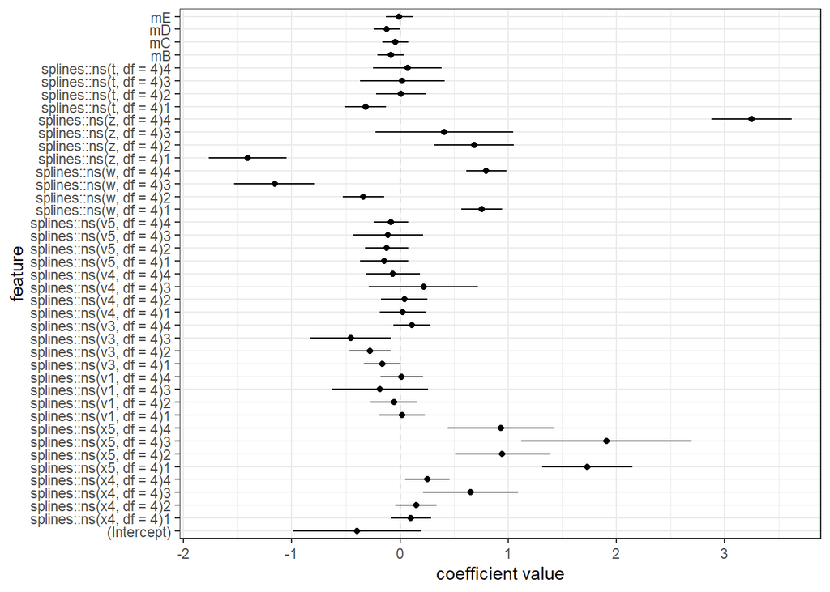

```r
viz_post_coefs(laplace_8$mode[1:ncol(Xmod8)],
               sqrt(diag(laplace_8$var_matrix)[1:ncol(Xmod8)]),
               colnames(Xmod8))
```

For model-8 **z** and **x5** looks most significant.

[figure not shown]

```r
viz_post_coefs(laplace_12$mode[1:ncol(Xmod12)],
               sqrt(diag(laplace_12$var_matrix)[1:ncol(Xmod12)]),
               colnames(Xmod12))
```

For model-12 too **z** and **x5** are most significant features.

```r
viz_grid <- expand.grid(x1 = median(df_derived_scaled$x1),
                        x2 = median(df_derived_scaled$x2),
                        x3 = median(df_derived_scaled$x3),
                        x4 = median(df_derived_scaled$x4),
                        x5 = seq(min(df_derived_scaled$x5), max(df_derived_scaled$x5), length.out = 5),
                        v1 = median(df_derived_scaled$v1),
                        v2 = median(df_derived_scaled$v2),
                        v3 = median(df_derived_scaled$v3),
                        v4 = median(df_derived_scaled$v4),
                        v5 = median(df_derived_scaled$v5),
                        w = seq(min(df_derived_scaled$w), max(df_derived_scaled$w), length.out = 5),
                        z = seq(min(df_derived_scaled$z), max(df_derived_scaled$z), length.out = 101),
                        t = median(df_derived_scaled$t),
                        m = unique(df_derived_scaled$m),
                        KEEP.OUT.ATTRS = FALSE,
                        stringsAsFactors = FALSE) %>%
  as.data.frame() %>% tibble::as_tibble()

viz_grid %>% glimpse()
```

```
## Rows: 12,625
## Columns: 14
## $ x1 <dbl> 0.08818945, 0.08818945, 0.08818945, 0.08818945, 0.08818945, 0.08818…
## $ x2 <dbl> 0.109188, 0.109188, 0.109188, 0.109188, 0.109188, 0.109188, 0.10918…
## $ x3 <dbl> 0.007119913, 0.007119913, 0.007119913, 0.007119913, 0.007119913, 0.…
## $ x4 <dbl> 0.1012426, 0.1012426, 0.1012426, 0.1012426, 0.1012426, 0.1012426, 0…
## $ x5 <dbl> -1.3511623, -0.1368703, 1.0774217, 2.2917137, 3.5060057, -1.3511623…
## $ v1 <dbl> 0.02131527, 0.02131527, 0.02131527, 0.02131527, 0.02131527, 0.02131…
## $ v2 <dbl> 0.04371815, 0.04371815, 0.04371815, 0.04371815, 0.04371815, 0.04371…
## $ v3 <dbl> 0.02532552, 0.02532552, 0.02532552, 0.02532552, 0.02532552, 0.02532…
## $ v4 <dbl> -0.008900144, -0.008900144, -0.008900144, -0.008900144, -0.00890014…
## $ v5 <dbl> 0.179781, 0.179781, 0.179781, 0.179781, 0.179781, 0.179781, 0.17978…
## $ w  <dbl> -1.78839938, -1.78839938, -1.78839938, -1.78839938, -1.78839938, -0…
## $ z  <dbl> -1.461784, -1.461784, -1.461784, -1.461784, -1.461784, -1.461784, -…
## $ t  <dbl> -0.08333946, -0.08333946, -0.08333946, -0.08333946, -0.08333946, -0…
## $ m  <chr> "A", "A", "A", "A", "A", "A", "A", "A", "A", "A", "A", "A", "A", "A…
```

```r
generate_lm_post_samples <- function(mvn_result, length_beta, num_samples)
{
  MASS::mvrnorm(n = num_samples,
                mu = mvn_result$mode,
                Sigma = mvn_result$var_matrix) %>%
    as.data.frame() %>% tibble::as_tibble() %>%
    purrr::set_names(c(sprintf("beta_%02d", 0:(length_beta-1)), "varphi")) %>%
    mutate(sigma = exp(varphi))
}
```

```r
post_lm_pred_samples <- function(Xnew, Bmat, sigma_vector)
{
  # number of new prediction locations
  M <- nrow(Xnew)
  # number of posterior samples
  S <- nrow(Bmat)

  # matrix of linear predictors
  Umat <- Xnew %*% t(Bmat)

  # assmeble matrix of sigma samples, set the number of rows
  Rmat <- matrix(rep(sigma_vector, M), M, byrow = TRUE)

  # generate standard normal and assemble into matrix
  # set the number of rows
  Zmat <- matrix(rnorm(M*S), M, byrow = TRUE)

  # calculate the random observation predictions
  Ymat <- Umat + Rmat * Zmat

  # package together
  list(Umat = Umat, Ymat = Ymat)
}
```

```r
make_post_lm_pred <- function(Xnew, post)
{
  Bmat <- post %>% select(starts_with("beta_")) %>% as.matrix()

  sigma_vector <- post %>% pull(sigma)

  post_lm_pred_samples(Xnew, Bmat, sigma_vector)
}
```

```r
summarize_lm_pred_from_laplace <- function(mvn_result, Xtest, num_samples)
{
  # generate posterior samples of the beta parameters
  post <- generate_lm_post_samples(mvn_result, ncol(Xtest), num_samples)

  # make posterior predictions on the test set
  pred_test <- make_post_lm_pred(Xtest, post)

  # calculate summary statistics on the predicted mean and response
  # summarize over the posterior samples

  # posterior mean, should you summarize along rows (rowMeans) or
  # summarize down columns (colMeans) ???
  mu_avg <- rowMeans(pred_test$Umat)
  y_avg <- rowMeans(pred_test$Ymat)

  # posterior quantiles for the middle 95% uncertainty intervals
  mu_lwr <- apply(pred_test$Umat, 1, stats::quantile, probs = 0.025)
  mu_upr <- apply(pred_test$Umat, 1, stats::quantile, probs = 0.975)
  y_lwr <- apply(pred_test$Ymat, 1, stats::quantile, probs = 0.025)
  y_upr <- apply(pred_test$Ymat, 1, stats::quantile, probs = 0.975)

  # book keeping
  tibble::tibble(
    mu_avg = mu_avg,
    mu_lwr = mu_lwr,
    mu_upr = mu_upr,
    y_avg = y_avg,
    y_lwr = y_lwr,
    y_upr = y_upr
  ) %>%
    tibble::rowid_to_column("pred_id")
}
```

**Function to create spline knots**

```r
make_splines_training_knots <- function(J, train_data, xname)
{
  x <- train_data %>% select(all_of(xname)) %>% pull()

  train_basis <- splines::ns(x, df = J)

  as.vector(attributes(train_basis)$knots)
}
```

**Function to create boundary knots**

```r
make_splines_boundary_knots <- function(J, train_data, xname)
{
  x <- train_data %>% select(all_of(xname)) %>% pull()

  train_basis <- splines::ns(x, df = J)

  as.vector(attributes(train_basis)$Boundary.knots)
}
```

**Creating spline knots for both models**

```r
x4_spline_knots <- make_splines_training_knots(4, df_derived_scaled, as.character("x4"))
x5_spline_knots <- make_splines_training_knots(4, df_derived_scaled, as.character("x5"))

v1_spline_knots <- make_splines_training_knots(4, df_derived_scaled, as.character("v1"))
v3_spline_knots <- make_splines_training_knots(4, df_derived_scaled, as.character("v3"))
v4_spline_knots <- make_splines_training_knots(4, df_derived_scaled, as.character("v4"))
v5_spline_knots <- make_splines_training_knots(4, df_derived_scaled, as.character("v5"))

w_spline_knots <- make_splines_training_knots(4, df_derived_scaled, as.character("w"))
z_spline_knots <- make_splines_training_knots(4, df_derived_scaled, as.character("z"))
t_spline_knots <- make_splines_training_knots(4, df_derived_scaled, as.character("t"))
```

**Creating boundary knots for models**

```r
x4_bknots <- make_splines_boundary_knots(4, df_derived_scaled, as.character("x4"))
x5_bknots <- make_splines_boundary_knots(4, df_derived_scaled, as.character("x5"))

v1_bknots <- make_splines_boundary_knots(4, df_derived_scaled, as.character("v1"))
v3_bknots <- make_splines_boundary_knots(4, df_derived_scaled, as.character("v3"))
v4_bknots <- make_splines_boundary_knots(4, df_derived_scaled, as.character("v4"))
v5_bknots <- make_splines_boundary_knots(4, df_derived_scaled, as.character("v5"))

w_bknots <- make_splines_boundary_knots(4, df_derived_scaled, as.character("w"))
z_bknots <- make_splines_boundary_knots(4, df_derived_scaled, as.character("z"))
t_bknots <- make_splines_boundary_knots(4, df_derived_scaled, as.character("t"))
```

**Crating design matrix for model-8**

```r
Xviz_8 <- model.matrix( ~ splines::ns(z, knots = z_spline_knots, Boundary.knots = z_bknots) +
                          splines::ns(w, knots = w_spline_knots, Boundary.knots = w_bknots) +
                          splines::ns(t, knots = t_spline_knots, Boundary.knots = t_bknots) +
                          splines::ns(x4, knots = x4_spline_knots, Boundary.knots = x4_bknots) +
                          splines::ns(x5, knots = x5_spline_knots, Boundary.knots = x5_bknots) +
                          splines::ns(v1, knots = v1_spline_knots, Boundary.knots = v1_bknots) +
                          splines::ns(v3, knots = v3_spline_knots, Boundary.knots = v3_bknots) +
                          splines::ns(v4, knots = v4_spline_knots, Boundary.knots = v4_bknots) +
                          splines::ns(v5, knots = v5_spline_knots, Boundary.knots = v5_bknots) +
                          m,
                        data = viz_grid)
```

**Crating design matrix for model-12**

```r
Xviz_12 <- model.matrix( ~ (splines::ns(z, knots = z_spline_knots, Boundary.knots = z_bknots) +
                          splines::ns(w, knots = w_spline_knots, Boundary.knots = w_bknots) +
                          splines::ns(t, knots = t_spline_knots, Boundary.knots = t_bknots) +
                          splines::ns(x4, knots = x4_spline_knots, Boundary.knots = x4_bknots) +
                          splines::ns(x5, knots = x5_spline_knots, Boundary.knots = x5_bknots) +
                          splines::ns(v1, knots = v1_spline_knots, Boundary.knots = v1_bknots) +
                          splines::ns(v3, knots = v3_spline_knots, Boundary.knots = v3_bknots) +
                          splines::ns(v4, knots = v4_spline_knots, Boundary.knots = v4_bknots) +
                          splines::ns(v5, knots = v5_spline_knots, Boundary.knots = v5_bknots)) *
                          m,
                        data = viz_grid)
```

**Prediction on model-8**

```r
set.seed(7899)

post_pred_summary_8 <- summarize_lm_pred_from_laplace(laplace_8, Xviz_8, 5000)
```

**Prediction on model-12**

```r
set.seed(7899)

post_pred_summary_12 <- summarize_lm_pred_from_laplace(laplace_12, Xviz_12, 5000)
```

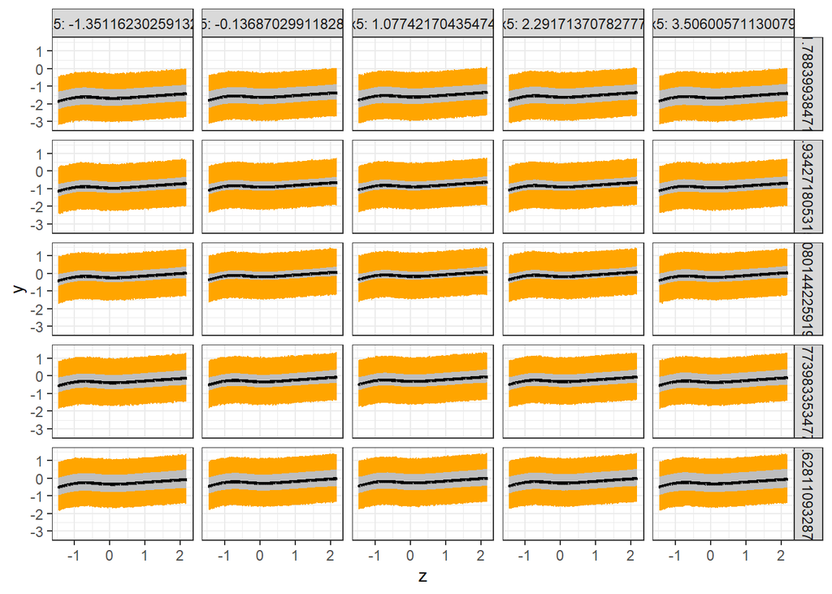

```r
post_pred_summary_8 %>%
  left_join(viz_grid %>% tibble::rowid_to_column("pred_id"),
            by = 'pred_id') %>%
  ggplot(mapping = aes(x = z)) +
  geom_ribbon(mapping = aes(ymin = y_lwr,
                            ymax = y_upr),
              fill = 'orange') +
  geom_ribbon(mapping = aes(ymin = mu_lwr,
                            ymax = mu_upr),
              fill = 'grey') +
  geom_line(mapping = aes(y = mu_avg),
            color = 'black') +
  facet_grid(w~x5, labeller = "label_both") +
  labs(y = 'y') +
  theme_bw()
```

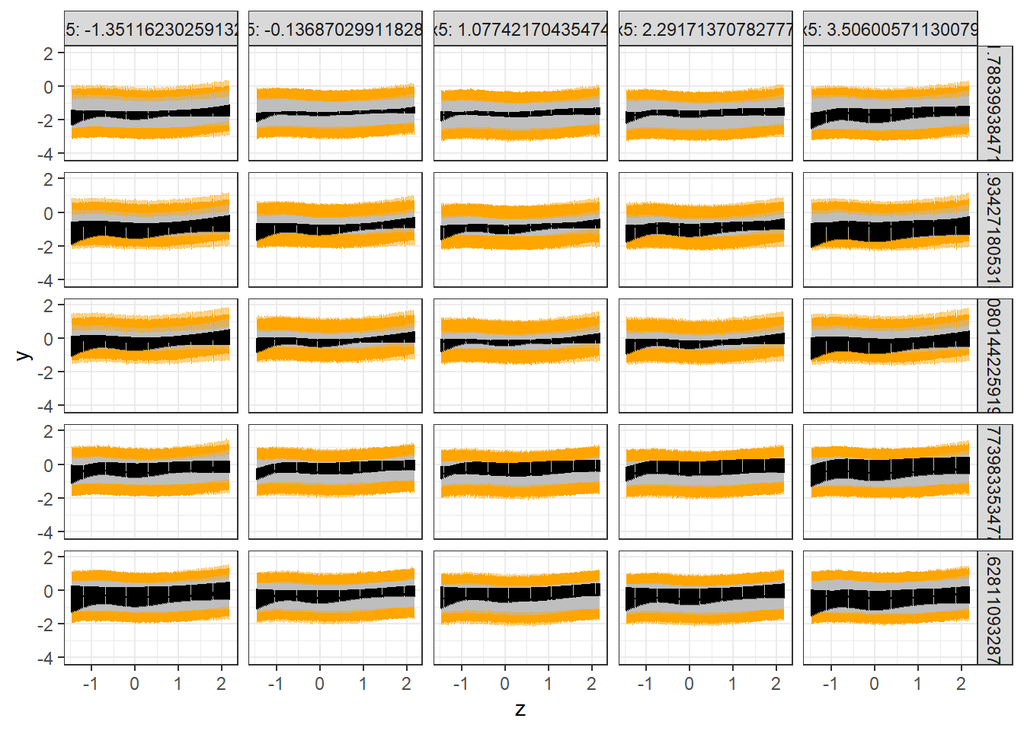

```r
post_pred_summary_12 %>%
  left_join(viz_grid %>% tibble::rowid_to_column("pred_id"),
            by = 'pred_id') %>%
  ggplot(mapping = aes(x = z)) +
  geom_ribbon(mapping = aes(ymin = y_lwr,
                            ymax = y_upr),
              fill = 'orange') +
  geom_ribbon(mapping = aes(ymin = mu_lwr,
                            ymax = mu_upr),
              fill = 'grey') +
  geom_line(mapping = aes(y = mu_avg),
            color = 'black') +
  facet_grid(w~x5, labeller = "label_both") +
  labs(y = 'y') +
  theme_bw()
```